# Predicting the Largest Floods in Canadian Rivers

Marian Agyby, Samson Bakos, Spencer Gerlach, Zilong Yi

2023-06-28

# Executive Summary

This project focuses on the prediction of flood magnitudes in Canadian rivers. While the flows of many rivers are actively monitored, many more are not. Estimates of maximum flow in these unmonitored rivers are necessary to guide engineering decisions in the surrounding areas. Existing methods for flood magnitude prediction have not been updated to keep pace with modern statistical techniques, and may provide less reliable estimations of flood magnitude. As ML becomes more ubiquitous and sophisticated, it is becoming clear that traditional RFFA methods could benefit from integrating these modern ML and statistical techniques. This project updates the existing methodology used by BGC, outlined by the United States Geological Survey (USGS), using modernized machine learning (ML) and applied statistics techniques.

The University of British Columbia Master of Data Science (UBC MDS, or MDS) team pursued two main approaches to complete this objective: The Index Flood Method (IFM) and Direct Quantile Method (DQM). The IFM combined unsupervised (hierarchical) clustering, supervised ML predictions of the index flood, and statistical distribution fitting to predict high river flow quantiles. The DQM used supervised ML quantile regression models to predict high flow quantiles directly. Both approaches present statistical and empirical improvements over existing methods.

The ML approaches have some limitations, such as the existence of an overprediction bias at the highest quantiles for IFM and DQM, and the need to modify the current clustering approach to increase the reasonability of statistical assumptions for IFM. However, the MDS team clearly documents the potential benefits of adopting the outlined approach, as well as suggesting next steps to address limitations and improve the two approaches.

This document provides clear proof-of-concept and justification for the application of ML in the prediction of flood magnitudes. The MDS team has provide pre-trained models that can be deployed with minor adjustments, and the MDS team recommends the adoption of the outlined methodology to improve the accuracy of BGC’s flood magnitude prediction.

# List of Acronyms

| Acronym | Meaning |
| --- | --- |
| AEP | Annual Exceedance Probability |
| AMS | Annual Maxima Series |
| DQM | Direct Quantile Method |
| FFA | Flood Frequency Analysis |
| IFM | Index Flood Method |
| L-CV | L-Coefficient of Variation |
| MAPE | Mean Absolute Percentage Error |
| MDS | Master of Data Science |
| ML | Machine Learning |
| MLE | Maximum Likelihood Estimation |
| MSE | Mean Squared Error |
| PCA | Principal Component Analysis |
| RFFA | Regional Flood Frequency Analysis |
| RMSE | Root Mean Squared Error |
| UBC | University of British Columbia |
| USGS | United States Geological Survey |

# Introduction

River floods pose a significant threat to various aspects of society, including urban safety, agriculture, and transportation. To mitigate the effects of floods, engineers rely on estimations of the magnitude of different flood severities through a process called Flood Frequency Analysis (*Hydrology of Floods in Canada* 1989) which quantifies “flood severities” as quantiles of annual maximum river flows.

A Flood Frequency Analysis (FFA) estimates quantiles of annual maximum river flows by fitting a probability distribution to annual maximum flow values (*Hydrology of Floods in Canada* 1989). These annual maxima are obtained from data measured daily or sub-daily by a river flow gauge. The distribution of maximum flows is used to determine the annual exceedance probability (AEP), which is the complement of a given quantile level ($\text{AEP} = 1 - \text{quantile level}$), or the return period, which is the inverse of the AEP ($\text{return period} = 1 / \text{AEP}$). The 0.5% AEP (i.e. a return period of 200 years) is often called the “design flood” and is typically considered the standard for engineering decisions (EGBC 2018).

FFAs are conducted on individual, monitored rivers with available flow data. To extend this analysis to unmonitored rivers, analysts use a Regional Flood Frequency Analysis (RFFA). RFFA is a type of FFA that groups similar rivers together such that all their flow data can be combined. RFFA uses combined data from monitored rivers to estimate flow quantiles in similar unmonitored rivers (*Hydrology of Floods in Canada* 1989).

However, existing methods of RFFA have not been updated to keep pace with modern statistical techniques, and may provide less reliable estimations of flood magnitude. As ML becomes more ubiquitous and sophisticated, it is becoming clear that traditional RFFA methods could benefit from integrating these modern ML and statistical techniques.

The goal of this project was to employ modern ML algorithms and refinements to the statistical methodology of RFFA to enhance existing approaches and create more accurate predictions for high return period floods, specifically the 0.5% AEP design flood. Success was evaluated empirically by demonstrating improved quantile scores (a specific method to evaluate quantile predictions) on the design flood (and other high quantiles) for holdout gauges from the ML models compared to the current BGC approach baseline. Ongoing success will also be based on buy-in and feedback from BGC’s engineers and hydrologists.

# Project Deliverables

There are two primary deliverables presented by the MDS team to BGC:

1. GitLab repository containing a `python` script (`flood_predictor.py`) that generates river flow quantile predictions for new watersheds, and supporting analysis collected in Jupyter Notebooks.
2. Report document that justifies a transition to ML-based RFFA based on the analysis completed by the MDS team in May-June 2023.

The script is intended to inform improvements to existing software, and the functions and code within the script and notebooks is intended to become the basis for a final production-ready product.

This report and its appendices are intended to provide justification for the transition to an ML-based approach for river flow quantile prediction. As a result, the report includes analysis that supports this transition. The contents of the report, and external content located in the project repository should be considered important reference material in any future decision to finalize a transition to ML-based quantile predictions.

If time had permitted, the MDS team would have included the following items in the project scope:

- Test the integration of the script deliverable into BGC’s GitLab environment, ensuring the scripts could be run locally via the GitLab repository.
- Automate the ML model re-training process via reproducible command line scripting tools, such as GNU Make `makefile`.
- Create a companion dashboard to provide context to predicted values via:
  - visualizing the IFM growth curve
  - displaying SHAP force plots explaining the prediction
  - check for outlier predictions via PCA plots

These features could be implemented in Cambio by repurposing or expanding exploratory code in the repository notebooks.

# Machine Learning for RFFA

The project had four major stages:

1. Data Prep and Cleaning
2. Unsupervised Clustering
3. ML-based Quantile Flow Prediction for IFM
4. ML-based Quantile Flow Prediction for DQM

The flowchart below describes the project development process, simplified in some areas for ease of visual understanding. The figure is an abstraction of technical coding processes completed with the python and R programming languages, and contained within Jupyter Notebooks and `.R` and `.py` scripting files.

The important components of the figure will be explained in the upcoming report sections.

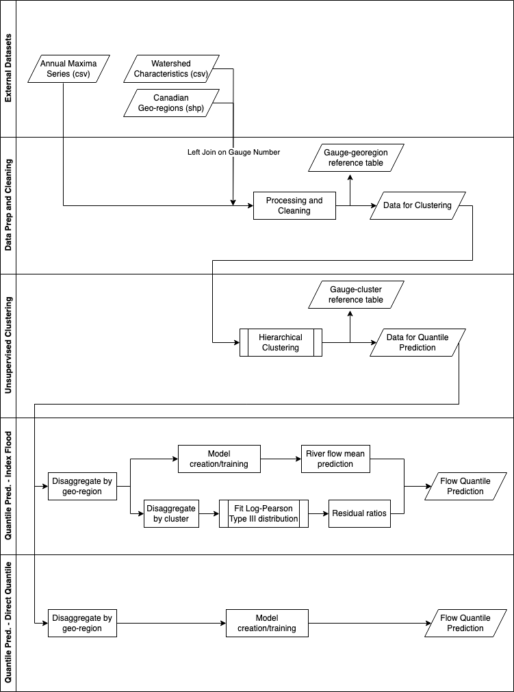

Figure 1: Flowchart of Project Development Process

## Data Cleaning and Prep

The first stage of the project was to convert the raw input data into a format that is suitable for a supervised machine learning application. There were three major external datasets used in the project:

1. **Annual Maxima Series (AMS) data**: Instantaneous maximum annual river flow values for multiple years at various flow gauges across the prairies, boreal plains, and boreal shield regions of Canada. This data was the “target” column of the supervised ML process.
2. **Watershed Characteristics**: Various hydrological features of watersheds. This data was the “features” part of the supervised ML process, and was used to predict the “target” i.e. the instantaneous maximum annual flow.
3. **Canadian Geo-regions (`.shp`)**: Geospatial representation of Canada’s geo-regions. Used to assign correct georegion labels (e.g. prairies, boreal plain, boreal shield) to gauges across Canada.

The raw and cleaned datasets can be viewed in the `data/` subdirectory of the project repository.

The data cleaning, prep work, and exploratory data analysis can be found in the `.ipynb` notebooks in the `reports/EDA` subdirectory of the project repository, and more explanation on steps undertaken can be found in the Appendix: IFM Data Preprocessing section.

A significant outcome of the data preparation stage was the creation of “training” and “testing” data splits for the ML models. The full dataset is split into two groups, the larger split (approx. 70%), training data, was used to learn relationships between the features and target outcome. The smaller split (approx. 30%), testing data, was used to evaluate how closely model predictions matched actual flow values.

## Unsupervised Clustering

The unsupervised clustering process built homogenous groups within the data to improve adherence statistical assumptions and ultimately improve the accuracy of predictions. A detailed description can be found in section the Appendix: Regional Homogeneity, Clustering and H-Index section.

## Index Flood Method

### Background

IFM for RFFA relies on the combination of two components:

1. **Index Flood Prediction**: The predicted mean of logged instantaneous maximum annual flows. The prediction is based on the learned relationship between the watershed characteristics and observed flows of monitored rivers.
2. **Growth Curve**: The relationship between river flow frequency and residual ratios. Residual ratios are the observed flow quantile divided by the observed geometric mean of flow (see equation below). The curve itself is a statistical distribution fit to the flow frequency versus residual ratio data.

$$\text{residual ratio quantile} =
\frac{\text{observed flow quantile}}{\text{observed geomean
flow}}$$

These two components are implemented within the current industry methodology as such:

1. The index flood prediction is generated via a standard un-regularized linear regression on all watershed characteristics, with watershed area transformed to log base-10.
2. A combined (or “pooled”) statistical distribution is created for similar river groups. To do this, l-moments are calculated for each gauge, averaged, then a distribution is fit to the averaged l-moments. Multiple statistical distributions are fit to determine the best one. A list of candidate distributions and an illustrative figure is shown later in the report, in the Growth Curves section.

The MDS team improved RFFA IFM methodology via the following changes:

1. **Index Flood Prediction with Machine Learning**:
- **Random Forest Model**: Replaced linear regression with a modern ML algorithm, specifically a Random Forest Regressor. Random Forests learn complicated, non-linear relationships between the features and the target flows, and are more resilient to high dimensionality and co-linearity.
- **Training and evaluation criteria**: The objective of linear regression is to minimize the squared error. Rivers with larger flows tend to have large prediction errors, which are then squared. Minimizing squared error causes the model to favor reducing error on large rivers, often at the expense of accuracy for small rivers. To address this, the MDS team used an alternative training and evaluation criteria, discussed in the Evaluation Metrics section. It is worth noting that transforming instantaneous maximum annual flows to log base-10 did also partially alleviate this issue, but it did not fully resolve it.
2. **Improved Growth Curves**: Replaced the method of l-moments with distributions directly fit to predefined sub-sections of the data using Maximum Likelihood Estimation (MLE). Fitting to larger sub-sections of the data reduces the potential sample penalty incurred when making estimations based on small, gauge-level samples.

### Index Flood Model: Model Selection and Justification

Model selection for this project was based on two differing but important definitions of a “model”:

1. The type of machine learning model to use: E.g. Random Forest Regressor.
2. The data used to create the model:
- The model is trained on full undivided training data (one model), OR
- The model is trained on disaggregated sections of the training data separately (one model per data sub-section).

#### Evaluation Metrics

Making model selection decisions was based on multiple numeric evaluation metrics and visual evaluation strategies. Due to the unique structure of the river data and the default algorithms in ML model training software, the MDS team used a combination of custom and pre-existing numeric evaluation metrics. ML model performance was evaluated using Weighted Root Mean Squared Error (wRMSE), R-squared, and Mean Absolute Percentage Error (MAPE). wRMSE required a custom implementation, which is described in the Appendix: IFM Evaluation Metric Selection section.

ML models were also evaluated visually, using figures such as Prediction vs. Observed plots. These plots show the predicted value on one axis, and the observed value on the other axis. A diagonal line is plotted on the figure to represent predictions that are equal to observed values. Other important numerical evaluation criteria, such as quantile scores, are plotted visually to aid decision making.

#### Model Selection: Model Type

Other models tested include:

- **Baseline linear model**: Linear regression model with unscaled numerical watershed characteristics, and log base-10 watershed area. No regularization to prevent overfitting. This baseline model is considered a proxy for the current BGC process, and is used as a basis for comparison.
- **Regularized linear regression models**: Lasso (L1-regularization) and Ridge (L2-regularization).
- **Ensemble models**: Random Forest regression, XGBoost regression, and LightGBM regression models were all explored.

Neural network models were not explored due to a prioritization of model explainability. However, future improvements to this study may wish to explore neural networks for their ability to learn complex relationships and implement custom loss functions.

**Table 1: Performance of Candidate Index Flood Models on Test Data**

| Model | Weighted RMSE | R-squared | Mean Absolute Percentage Error (%) |
| --- | --- | --- | --- |
| Linear (Baseline) | 10.33 | 0.44 | 404 |
| Linear (Lasso) | 24.25 | 0.67 | 144 |
| Linear (Ridge) | 24.22 | 0.65 | 162 |
| Random Forest | 8.92 | 0.85 | 124 |
| XGBoost | 2.60 | 0.82 | 153 |
| LightGBM | 27.00 | 0.66 | 265 |

Data reference: `reports/ML-exploration/ML-approach-1_sg_v2.ipynb`

#### Model Selection: Training Data Structure

The choice of whether to dis-aggregate training data, and therefore the choice of how many models to train, can affect the accuracy of predictions. Training one model on overall data is beneficial due to the larger size of training data, but training a separate model for each geo-region (for example), may improve internal prediction accuracy within regions.

A random forest regression model was scored on test data to inform this decision. First, one random forest model was trained on the full train dataset. Second, the model based on full training data was compared to two sets of models, trained on the following sub-sections of the training data:

- Disaggregated by georegion (3 separate models): one model per georegion in the training data (prairies, boreal plain, and boreal shield).
- Disaggregated by cluster (4 separate models): one model per latent homogeneous cluster in the training data, as discovered via the hierarchical clustering process (cluster 1, cluster 2, cluster 3, cluster 4).

To compare disaggregated models to the overall model trained on all data, the overall model was scored on disaggregated test data. The figure below gives a visual explanation of this process. In the table below, the `Pair for Comparison` column is used to define how to pair the rows of the table to make comparisons between approaches. E.g. the `A-A` comparison would compare the overall model trained on full train data scored on test data filtered for prairies to the disaggregated model trained on train data filtered for prairies scored on test data filtered for prairies.

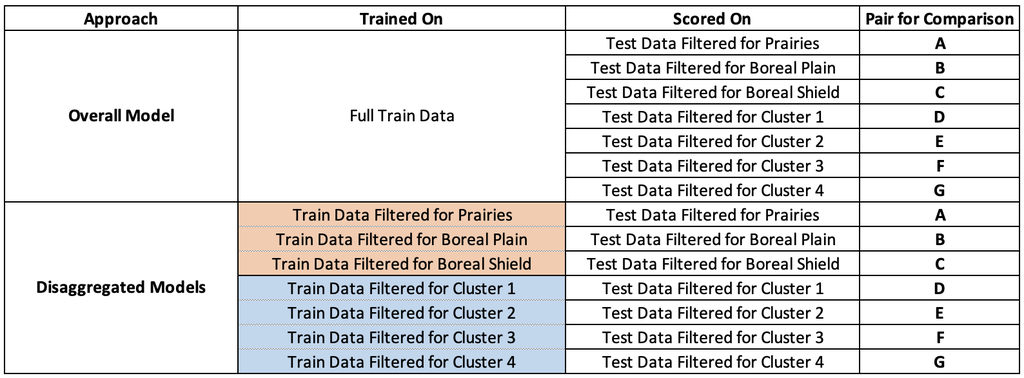

Table 2: List to Explain Data Structure Comparisons

Numerical and visual results showed that models disaggregated by georegion produced the best performance on unseen test data. Detailed results can be found in the `proj-floods/reports/ML-exploration/ML-approach-1_sg_v2.ipynb` Jupyter Notebook, in the section `Numeric Evaluation Method 1: Score overall model on different subsets of train data`.

#### Index Flood Model: Results and Evaluation

The figure below is a Predicted vs. Actual plot for index flood predictions. It shows evidence that the index flood predictions from the ML approach were much closer to the actual index flood values, compared to a baseline linear model (proxy for the conventional IFM prediction method).

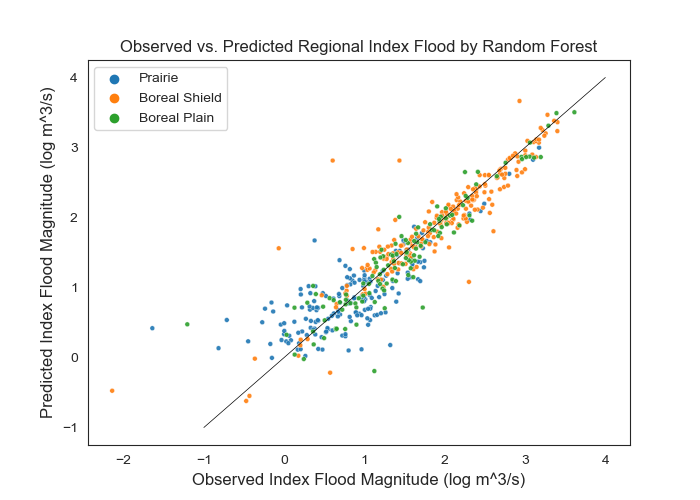

Figure 2: Gauge vs. Predicted Regional Index Flood by Random Forest Model

Caption: River Flow Index Flood Prediction from Random Forest ML Model plotted against Observed River Index Flood, Colored by Gauge Georegion. Each point represents a gauge. Data reference: `reports/ML-exploration/ML-approach1-ma.ipynb`

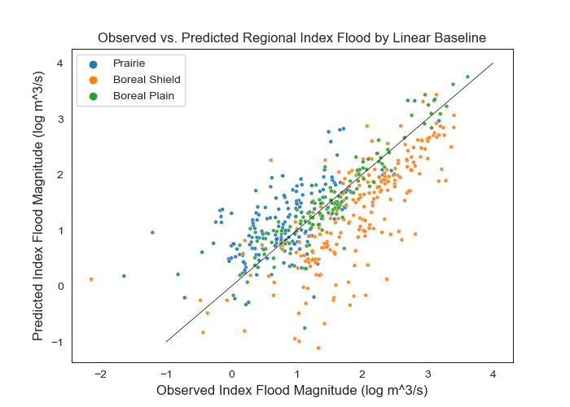

Figure 3: Gauge vs. Predicted Regional Index Flood by Linear Baseline Model

Caption: River Flow Index Flood Prediction from Linear Baseline Model plotted against Observed River Flow Index Flood, Colored by Gauge Georegion. Each point represents a gauge. Data reference: `reports/ML-exploration/ML-approach1-ma.ipynb`

### Growth Curves

Growth curves provide the essential scaling factor required to convert the index flood prediction to a desired quantile flow magnitude.

To create a growth curve, a statistical distribution is chosen from a list of candidate distributions based on how well it fits AEP vs residual ratio data. The list below is a collection of the most common distributions used in industry:

- Gumbel
- Log-Normal
- Log-Pearson Type 3
- Normal
- Pearson Type 3

The best distributional parameters for each were selected by Maximum Likelihood Estimation (MLE) / maximum goodness-of-fit estimation (MGE). Mean quantile losses were then used to choose the most suitable distribution. Other methods could have been used to choose the best distribution; this is discussed in the Appendix: Expanded Limitations section.

#### Disaggregated Statistical Distributions

Statistical distributions were fit to homogenous sub-sections of the data, rather than at the individual gauge level or to overall data. The data was disaggregated by both geo-region (prairies, boreal plain, boreal shield) and hierarchical cluster (cluster 1-4). This provided the most homogenous groups, based on findings from the clustering analysis (refer to Appendix: Regional Homogeneity, Clustering and H-Index for a detailed description of clustering).

> Note: Trained ML models were disaggregated by geo-region only, while the statistical distributions were disaggregated by both geo-region and cluster. The objective of the ML model is to create accurate index flood predictions, while the objective of creating growth curves is to use the most homogenous groups to address homogeneity requirements.

Fitting on disaggregated data resulted in 60 distributions ($\text{3 geo-regions} \times \text{4 clusters} \times \text{5 candidate distributions}$). However, there are no gauges in Boreal Shield and Cluster 1, meaning only 55 distributions are created ($[(\text{3 geo-regions} \times \text{4 clusters)}-1] \times \text{5 candidate distributions}$).

Each distribution describes the relationship between the AEP (or quantile level) and the residual ratio (flow quantile / index flood) for each data sub-section.

#### Log Pearson Type III

Based on mean quantile loss, the Log Pearson Type III distribution was the most suitable distribution across all sub-groups. Evidence of this is shown in the figure below. The Log Pearson Type III distribution performs best (low quantile loss) across most quantile levels; most importantly it performs best at the largest quantiles (furthest left on x-axis).

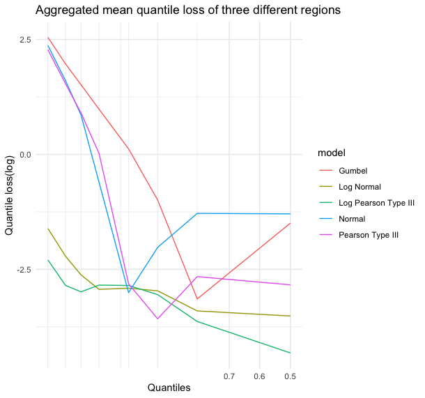

Figure 4: Mean Quantile Loss of Candidate Statistical Distributions

Caption: Mean quantile loss of five candidate distributions. Mean quantile loss is calculated across cluster and region to get an overall mean. Log Pearson Type III shows the lowest mean quantile loss across the most quantile levels, most importantly high quantiles (furthest left on x-axis). X-axis labels could not be fixed due to custom functions in `reports/Dist_ratio/scale_gumbel.R` that override label settings. Data reference: `reports/Dist_ratio/distribution_justification/distribution-justifications.R`

A numerical equivalent of the figure above can be viewed in the `reports/Dist_ratio/distribution_justification/distribution_justification.csv` file in the project repository.

To integrate the Log Pearson Type III distribution into the ML pipeline, a data table was created to relate each quantile level between 50% and 99.8% with a corresponding residual ratio for each of the 11 data sub-sections. These values were then used as scale-up factors for the index flood prediction to obtain a river flow quantile prediction.

### River Flow Quantile Prediction

Residual ratios act as scaling ratios for the index flood prediction, and are used to convert the index flood into a quantile prediction. Once the index flood prediction model was optimized, and the residual ratio relationships were developed for each subsection of the data, they are combined to create a river flow quantile prediction ($\text{River Flow Quantile} = 10^{\text{Index Flood Prediction}} \times \text{Residual Ratio from Growth Curve}$). Note that it is necessary to exponentiate the Index Flood prediction as it is generated by the ML model on the $log_{10}$ scale.

#### Methodology

For a given new watershed to be predicted, the methodology follows these steps:

1. Assign the watershed to its most likely geo-region (via spatial join), and cluster (via hierarchical clustering).
2. Get index flood prediction from Random Forest Model.
3. Based on geo-region and cluster combination, choose the corresponding growth curve.
4. For each quantile of interest, multiply the index flood prediction by the corresponding residual ratio to yield quantile flow predictions.

For example, for a new watershed in Boreal Plains and Cluster 3:

$$\text{Quantile Flow}_{\text{new
watershed, 0.995 quantile}} = \text{Residual Ratio}_{\text{0.995
quantile}} * 10^{\text{ML index flood prediction}_{\text{new
watershed}}}$$

$$= (\frac{\text{Quantile
Flow}_{\text{boreal plain, cluster 3, 0.995 quantile}}}{\text{Geomean
Flow}_{\text{boreal plain, cluster 3}}}) * 10^{\text{ML Index Flood
Prediction}_{\text{new watershed}}}$$

#### Performance Evaluation

The plots below illustrate the quantile loss scores for river flow quantile predictions across various different quantile levels, with smaller scores indicating better performance. The figure includes the following models:

- A conventional FFA process used to estimate the river flow quantile prediction when flow data is available. This is the benchmark for comparison.
- A proxy for the baseline RFFA methods used to estimate river flow quantiles in the absence of river flow data.
- The optimal ML model river flow quantile prediction in the absence of river flow data (RFFA), generated from the Random Forest Index Flood model.

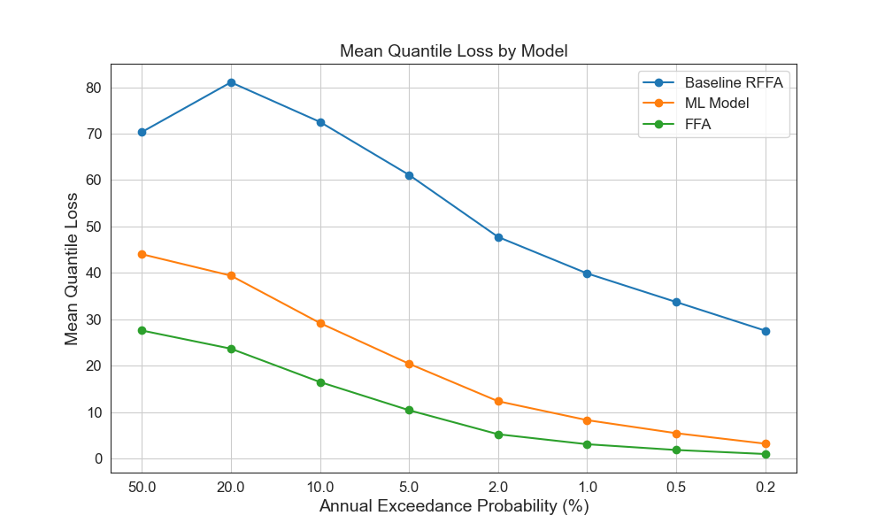

Figure 5: Mean Quantile Losses for River Flow Quantile Prediction Methods

Caption: Mean quantile losses for river flow quantile prediction methods. Lower scores are better. The ML model is closer to the FFA benchmark for quantile losses than the conventional RFFA approach (baseline). This indicates the ML model performs better than the conventional approach at predicting river flow quantiles. Data reference: `reports/ML-exploration/ML-approach1-ma.ipynb`

The figure shows that the ML model losses are closer to the FFA benchmark than the RFFA baseline. This confirms that the trained ML model outperforms the baseline based on quantile score. A raw, disaggregated version of this figure showing gauge-level quantile losses is available in the Appendix: Gauge-level Quantile Loss of IFM Quantile Flow Predictions section. Overall, there is strong evidence to suggest the ML model outperforms the baseline model at predicting high quantiles, including the 0.5% AEP.

## Direct Quantile Method

### Background

DQM for RFFA relies on a model that can predict river flow quantiles directly. The model uses monitored watersheds, similar to the unmonitored watershed in question, to predict quantile river flow directly. A significant component of this process is the determination of what constitutes a “similar watershed”.

The DQM approach is implemented within the current industry methodology as such:

- Given an unmonitored watershed of interest, select monitored watersheds with similar characteristics to the reference watersheds. This process relies on manual intervention by a hydrologist to group similar watersheds, though unsupervised (hierarchical) clustering is considered in complex situations.
- Fit selected watersheds with frequency-magnitude curves using standard FFA methodology (method of L-moments).
- For each desired quantile of interest in the unmonitored river, fit a linear regression with log(area) as a regressor and the quantile river flow of interest as the response. This linear regression can then be used to predict river flow quantiles for unmonitored watersheds.

The primary drawback to this method is the need for manual intervention. This requires domain knowledge to define and locate similar watersheds, and may also require localized expertise of specific hydrological regions. This encourages watershed selection based on similarity of features under the assumption it will improve downstream predictions.

The ML version of DQM instead uses all data to directly generate quantile predictions based on learned relationships between watershed characteristics and river flow quantiles. All gauges are used to create the model, not just gauges from similar watersheds. Watersheds with similar features should receive similar predictions due to the complex relationships learned by the ML model. This removes the requirement of manual intervention, but requires trust in the ML algorithm to learn the proper relationships.

### Model Selection

To implement DQM with ML, the MDS team used quantile regression algorithms available from various python libraries.

Candidate models included:

- Linear Quantile Regression
- Tree based ensemble models, such as:
  - Random Forest Quantile Regression
  - LightGBM Quantile Regression

The off-the-shelf implementations of the Linear Quantile Regression and LightGBM models required fitting one model per quantile level. Therefore, creating a range of quantile predictions per gauge required a combination of multiple models. This was not necessary for the Random Forest Quantile regression model, as a single model is able to learn multiple pre-specified quantile levels.

The loss function for quantile regression models minimizes quantile loss, where `q` is the non-exceedance probability of interest:

$L = \begin{cases} (1-q)|\hat{y}_q - y| & \text{if }y \lt \hat{y}_q \\ q|\hat{y}_q - y| & \text{if }y \ge \hat{y}_q \end{cases}$

This loss function is linear with respect to prediction error ($(\hat{y}_q - y)$). Therefore, this loss function suffers a similar error scale issue to the least squares loss function in the IFM index flood prediction (see Appendix: IFM Evaluation Metric Selection). However, in DQM this relationship is linear rather than quadratic as in IFM. Log-scaling flow was deemed sufficient to address the scale issue in DQM. As a result, a refit error metric was not required.

The Linear Quantile Regression model was chosen from the list of candidate models based on quantile loss score at high quantiles, as well as increased interpretability.

The figure below shows the mean quantile scores across all gauges for Linear Quantile Regression, Random Forest Quantile Regression, and LightGBM Quantile Regression.

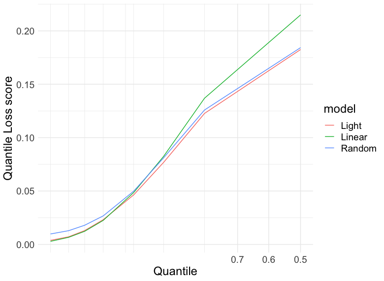

Figure 6: Mean Quantile Loss Scores of Candidate DQM ML Models

Caption: Mean quantile loss scores for DQM ML models. Smaller loss scores are better. Random Forest and LightGBM models outperform Linear model at low quantiles, but perform worse at high quantiles. Linear is marginally better than LightGBM at the highest quantiles. Data reference: `reports/Approach2/quantile-overall.ipynb`

While the Random Forest and LightGBM models outperformed the Linear model at low and mid-range quantiles, the Linear model slightly outperforms LightGBM at the highest quantile levels (furthest left on x-axis). The highest quantiles are most important (e.g. design flood at 0.5% AEP), so the linear quantile regression model was chosen as the best model.

### River Flow Quantile Prediction

The plots below illustrate the quantile loss scores for river flow quantile predictions across various different quantile levels, with smaller scores indicating better performance. The figure includes the following models:

- A conventional FFA process used to estimate the river flow quantile prediction when flow data is available. This is the benchmark for comparison.
- The optimal ML model river flow quantile prediction in the absence of river flow data (RFFA), generated from the Linear Quantile Regression model.

> Note: the figure below does not show an RFFA baseline comparison because creating this baseline requires manual intervention by a domain expert. This is difficult to complete at the same scale (all test data) that the ML model and FFA are applied at, so it is not shown.

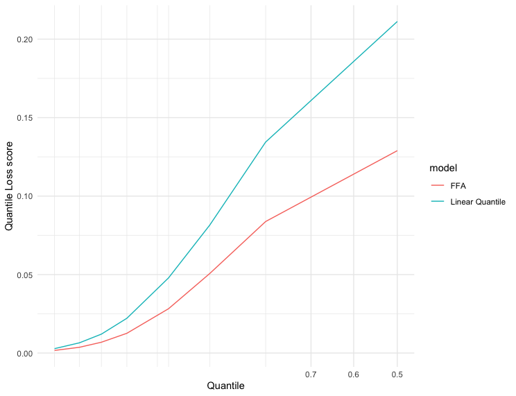

Figure 7: Quantile Score Comparison of FFA Benchmark to DQM Quantile Prediction

Caption: Quantile loss score comparison of FFA benchmark to DQM Linear Quantile regression predictions at different quantile levels. Linear quantile predictions approach FFA benchmark at higher quantiles. No RFFA baseline is available for comparison. Data reference: `reports/Approach2/quantile-overall.ipynb`

The figure shows that the ML model losses are close to the FFA benchmark. Due to the absence of an RFFA baseline, it is difficult to quantify the improvement of the ML model against the conventional RFFA approach. However, the quantile losses of the Linear Quantile Regression model are similar to the quantile losses from the IFM predictions. As a result, we could possibly arrive at a logical conclusion that the ML-based DQM provides a similar improvement to the baseline than the ML-based IFM does. However, without an accessible, concrete RFFA baseline this conclusion cannot be made definitively.

# Limitations

The following table gives a high-level overview of various limitations to the current analysis. An expanded version of this list can be viewed in the Appendix: Expanded Limitations section.

**Table 3: Project Limitations**

| Type | Description |
| --- | --- |
| Data Structure | Variable amounts of data at gauge level is not directly accounted for in the ML algorithms. |
| Data Structure | Grouped data (multiple years per gauge, multiple gauges) affects training/testing data split. |
| Data Structure | River flow magnitude is skewed, which cannot be fully dealt with. |
| Data Structure | Nested gauge structure means measurements across gauges are sometimes not statistically independent from each other. |
| Data Structure | Testing dataset size can be quite variable depending on which gauges are assigned to training/testing data. |
| Algorithmic and ML Limitations | Quantile scores are not scaled to river size |
| Algorithmic and ML Limitations | There is no accessible ground truth for Direct Quantile Method |
| Algorithmic and ML Limitations | The variation in instantaneous maximum daily flow within the prairies geo-region was not well-explained by the given watershed features. |
| Statistical Assumptions | Higher homogeneity could be achieved in unsupervised clustering. |
| Statistical Assumptions | The quantile predictions show some evidence of over-prediction. With the Index Flood model performing well, this is likely due to the residual ratio from the growth curve. |
| Statistical Assumptions | The most suitable statistical distribution was chosen via quantile scores. It could be chosen with other selection methods in future iterations. |
| Data Product Limitations | There is limited functionality for manual intervention (i.e. manual removal of river gauges). |
| Data Product Limitations | Retraining the ML models must be done via Jupyter Notebook. |
| Data Product Limitations | Direct Quantile Method has limited hyperparameter tuning due to the large number of models to train. |

# Future Improvements

The following list provides areas that the existing analysis could be improved in the future by BGC or future MDS capstone projects. The improvements listed are brief summaries, and the full description can be viewed in the Appendix: Expanded Future Improvements section.

**Table 4: Project Limitations**

| Improvement | Description |
| --- | --- |
| Explore a mixed effects model | Explore the effect of year on quantile prediction |
| Conduct data augmentation | Estimate instantaneous daily maximum via average daily maximum to increase data availability |
| Visualize outlier detection | Use clustering to create effective visualizations to find unusual watersheds |
| User more clusters | More clusters may improve the validity of homogeneity assumptions |
| Explore a new quantile prediction methodology | Create a model that serves as an intermediate between the IFM and DQM methodologies |
| Implement continuous DQM predictions | Implement a methodology to create continuous quantile predictions via DQM |

# Conclusions

Floods pose significant risk to both infrastructure and human life. Traditional RFFA methods could benefit from integrating modern ML and statistical techniques. This report justifies the transition to ML-based RFFA for both the Index Flood Method and Direct Quantile Method for RFFA. While the approaches detailed in this report have some statistical limitations and room for further improvement, the benefits of ML-based RFFA are apparent. The river flow quantile prediction script and supporting analysis developed by the MDS team should be used to supplement BGC’s Cambio software to improve the accuracy of BGC’s RFFAs. This report and the documentation of the accompanying repository provide a thorough proof-of-concept outline detailing both the improvements made, as well as avenues for further research. The report is a helpful reference to justify BGC’s transition toward ML-based RFFA.

# Appendices

## Appendix: Supporting Analysis for Index Flood Method

### IFM Data Preprocessing

Multiple preprocessing steps are required to get data suitable for the IFM. The following steps are required to ensure data is suitable for river flow quantile prediction.

**Table A1: IFM Preprocessing Steps**

[output not shown]

### IFM Evaluation Metric Selection

Loss functions are important in machine learning models because they define a quantity to be minimized to improve the overall accuracy of the model. The least squares loss function is ubiquitous, and is based on minimizing the squared difference between actual and predicted values. Common loss functions are coded directly into off-the-shelf machine learning modeling libraries, such as `scikit-learn`.

There are inherent limitations with using scikit-learn’s built-in squared error loss function for training the ML models on skewed data. Taking river flow as an example, squared error in large rivers will dominate overall squared error across all rivers (e.g. prediction errors of 100 $m^3/s$ in large rivers vs prediction errors of 1 $m^3/s$ in small rivers). As a result, squared error will prioritize reducing residuals in large rivers, as this is the most efficient way to reduce overall residuals. This issue is less prevalent on the log scale, but due to this modeling process being applied most often to small rivers, simply logging the target flows is insufficient to obtain the desired model fit.

To address this issue with squared error, the MDS team implemented a modified approach to training the scikit-learn models that incorporates the variable scale of river flow data.

Scikit-learn offers a `sample_weight` parameter within multiple models’ `.fit()` method. This parameter allows the user to indicate the relative importance or significance of each sample in the dataset. I.e. large river flows can be assigned a smaller weight, and small river flows can be assigned a larger weight. This prevents large rivers from dominating the squared error algorithm, and ensures all rivers are prioritized equally when the squared error algorithm is minimizing overall residuals. The `sample_weight` parameter accepts a list of numerical values that represent the weight to be assigned to each row in the training data.

Using the `sample_weight` parameter required the creation of a method to represent the weight of each gauge. The weight of each gauge was calculated as the inverse of the variance of logged river flow (log base-10 of the instantaneous maximum annual river flow). The magnitude of prediction error should be proportional to the standard deviation observed at that gauge, and therefore the squared prediction error should be proportional to the variance (standard deviation squared). Gauges on large rivers are assigned a small weight, as large rivers are expected to have large flow variation. As a result, the relative importance of all rivers in the squared error algorithm should be roughly equal. This approach is similar to the approach of weighted least squares, but the weights are fixed, rather than learned parameters.

A similar issue arose during hyperparameter tuning, where the best model hyperparameters minimize some objective scoring metric. Typical choices for this metric are root mean squared error (RMSE), R-squared, or even mean absolute percentage error (MAPE). However, all of these metrics have issues:

- RMSE shares the same limitation as least squares due to the order-of-magnitude variation in flow data.
- R-squared explains the degree of variance captured by a model, but does not directly optimize prediction accuracy. It’s possible to have a high R-squared value but poor predictive performance.
- MAPE is a promising metric to optimize the models as it is a relative scoring metric, which is helpful when the target has a variable scale. However, there are multiple limitations with using MAPE as an optimization criterion:
  - Sensitivity to zero or small actual values: MAPE is sensitive to cases where the actual values are close to zero or very small. When the denominator (actual value) approaches zero, the MAPE can become extremely large or undefined, leading to misleading or unreliable results. This sensitivity can make it challenging to compare models or make informed decisions during hyperparameter tuning.
  - Asymmetric treatment of errors: MAPE treats overestimations and underestimations differently. It penalizes overestimations more severely than underestimations since the error is divided by the actual value. Depending on the specific application, this asymmetric treatment may not align with the desired behavior of the model. In this situation of predicting the index flood, balanced errors are more desirable.

In response, the MDS team used the same weighted squared error approach, which incorporates the weights developed for model fitting, and applied them in a similar fashion to calculate root mean squared error, which tuning attempts to minimize.

Overall, there is no single scoring metric that can be used to select the optimal ML model in isolation. Throughout this analysis, multiple numeric evaluation metrics (weighted RMSE, R-squared, MAPE) and visual evaluation strategies (e.g. Prediction vs. Actual Plots) are used to choose the best overall model.

### Example Model Predictions

**Example 1 (07FB001): Example of an inaccurate IFM prediction**

*Qualification:*

- This gauge qualifies as inaccurate based on having a large difference between prediction and actual index flood value.

*Overview of predictions:*

**Table A2: Overview of 0.5% AEP Predictions for Gauge 07FB001**

| Component | From | Value |
| --- | --- | --- |
| Observed Value | Observed Index Flood | $1569 m^3/s$ |
| IFM: Index Flood Prediction | Baseline Model | $1232 m^3/s$ |
| IFM: Index Flood Prediction | ML Model | $730 m^3/s$ |
| FFA: 0.5% AEP Flood Benchmark | FFA | $ 6477 m^3/s$ |
| IFM: 0.5% AEP Flood Prediction | Baseline Model | $4540 m^3/s$ |
| IFM: 0.5% AEP Flood Prediction | ML Model | $8363 m^3/s$ |
| DQM: 0.5% AEP Flood Prediction | ML Model | $11820 m^3/s$ |

*Feature Importance via SHAP*

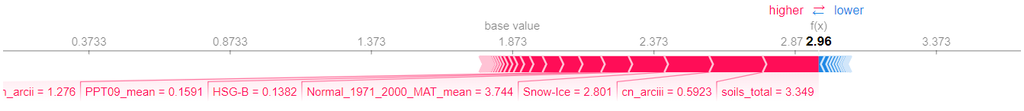

Figure A1: SHAP Force Plot of Features that Influence Prediction for Gauge 07FB001

*Feature Summary:*

**Table A3: Feature Summary of Watershed Upstream of Gauge 07FB001**

| Feature | Value |
| --- | --- |
| StationNum | 07FB001 |
| NameNom | PINE RIVER AT EAST PINE |
| Status | active |
| Area_km2 | 12136.3 |
| Date | 2021-12-17 |
| Normal_1971_2000_PAS_mean | 415.137 |
| Normal_1971_2000_MAT_mean | 0.963 |
| Normal_1971_2000_MAP_mean | 830.29 |
| PPT01_mean | 75.878 |
| PPT02_mean | 61.525 |
| PPT03_mean | 56.537 |
| PPT04_mean | 46.149 |
| PPT05_mean | 50.813 |
| PPT06_mean | 87.087 |
| PPT07_mean | 91.739 |
| PPT08_mean | 66.525 |
| PPT09_mean | 66.452 |
| PPT10_mean | 70.344 |
| PPT11_mean | 83.404 |
| PPT12_mean | 73.827 |
| PPT_wt | 211.23 |
| PPT_sp | 153.499 |
| PPT_sm | 245.35 |
| PPT_fl | 220.2 |
| Forest | 0.866 |
| Shrub | 0.097 |
| Wetland | 0.001 |
| Cropland | 0.017 |
| Urban-Barren | 0.012 |
| Water | 0.003 |
| Snow-Ice | 0.003 |
| landcover_total | 193247.0 |
| HSG-A | 0.0 |
| HSG-B | 0.0 |
| HSG-C | 0.841 |
| HSG-D | 0.003 |
| HSG-AD | 0.0 |
| HSG-BD | 0.0 |
| HSG-CD | 0.156 |
| HSG-DD | 0.0 |
| soils_total | 391997.0 |
| gmted_elev_min | 518.0 |
| gmted_elev_mean | 1150.842 |
| gmted_elev_max | 2297.0 |
| gmted_elev_range | 1779.0 |
| centre_elev | 1158.0 |
| cn_arci | 56.033 |
| cn_arcii | 74.352 |
| cn_arciii | 87.561 |
| centroid_lon | -121.547 |
| centroid_lat | 55.242 |
| Area_sqkm | 12125.769 |
| Length_km | 688.739 |
| Catchment_Length_m | 17605.755 |
| Catchment_Slope | 0.101 |
| cluster_label | 3 |
| region_label | Boreal Plain |

Data Reference: watershed characteristics data, cluster and region label generated by `flood_predictor.py`

**Example 2 (05PE028): Example of an accurate IFM prediction**

*Qualification:*

This gauge qualifies as accurate based on having a small difference between prediction and actual index flood value.

*Overview of predictions:*

**Table A4: Overview of 0.5% AEP Predictions for Gauge 05PE028**

| Component | From | Value |
| --- | --- | --- |
| Observed Value | Observed Index Flood | $ 804 m^3/s$ |
| IFM: Index Flood Prediction | Baseline Model | $ 417 m^3/s$ |
| IFM: Index Flood Prediction | ML Model | $ 744 m^3/s$ |
| FFA: 0.5% AEP Flood Benchmark | FFA | $ 1572 m^3/s$ |
| IFM: 0.5% AEP Flood Prediction | Baseline Model | $ 1538 m^3/s$ |
| IFM: 0.5% AEP Flood Prediction | ML Model | $ 2270 m^3/s$ |
| DQM: 0.5% AEP Flood Prediction | ML Model | $ 1992 m^3/s$ |

*Feature Importance via SHAP*

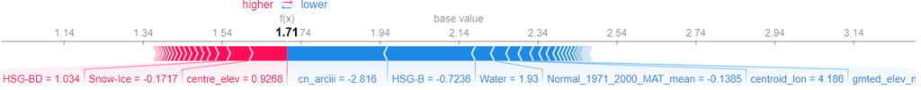

Figure A2: SHAP Force Plot of Features that Influence Prediction for Gauge 05PE028

Caption: To interpret the chart, note two things: the “base value” and the “f(x)” value. The “base value” represents a typical output, and the “f(x)” represents where the current output is. If the “f(x)” is right of the base value, this prediction is higher than expected, and vice versa. Columns on the red side of the spectrum work to push the prediction higher, while blue values work to push the prediction lower. In the chart above, `centre_elev` is the largest contributor to a high prediction, while `cn_arcii` is the largest contributor to lowering the prediction.

*Feature summary:*

**Table A5: Feature Summary of Watershed Upstream of Gauge 05PE028**

| Feature | Value |
| --- | --- |
| StationNum | 05PE028 |
| NameNom | WINNIPEG RIVER WESTERN CHANNEL NEAR TUNNEL ISLAND |
| Status | active |
| Area_km2 | 69526.300 |
| Date | 2022-06-17 |
| Normal_1971_2000_PAS_mean | 147.408 |
| Normal_1971_2000_MAT_mean | 2.680 |
| Normal_1971_2000_MAP_mean | 663.397 |
| PPT01_mean | 25.269 |
| PPT02_mean | 20.841 |
| PPT03_mean | 26.453 |
| PPT04_mean | 37.140 |
| PPT05_mean | 64.188 |
| PPT06_mean | 102.489 |
| PPT07_mean | 93.576 |
| PPT08_mean | 86.378 |
| PPT09_mean | 85.282 |
| PPT10_mean | 57.692 |
| PPT11_mean | 39.888 |
| PPT12_mean | 24.200 |
| PPT_wt | 70.309 |
| PPT_sp | 127.781 |
| PPT_sm | 282.442 |
| PPT_fl | 182.862 |
| Forest | 0.680 |
| Shrub | 0.014 |
| Wetland | 0.112 |
| Cropland | 0.018 |
| Urban-Barren | 0.001 |
| Water | 0.175 |
| Snow-Ice | 0.000 |
| landcover_total | 1108977.000 |
| HSG-A | 0.000 |
| HSG-B | 0.288 |
| HSG-C | 0.266 |
| HSG-D | 0.018 |
| HSG-AD | 0.001 |
| HSG-BD | 0.174 |
| HSG-CD | 0.000 |
| HSG-DD | 0.000 |
| soils_total | 1614456.000 |
| gmted_elev_min | 287.000 |
| gmted_elev_mean | 399.945 |
| gmted_elev_max | 629.000 |
| gmted_elev_range | 342.000 |
| centre_elev | 334.000 |
| cn_arci | 55.188 |
| cn_arcii | 73.260 |
| cn_arciii | 86.729 |
| centroid_lon | -92.917 |
| centroid_lat | 48.630 |
| Area_sqkm | 69484.767 |
| Length_km | 2061.676 |
| Catchment_Length_m | 33703.044 |
| Catchment_Slope | 0.010 |
| cluster_label | 4 |
| region_label | Boreal Shield |

Data Reference: watershed characteristics data, cluster and region label generated by `flood_predictor.py`

### Additional Figures

#### IFM: Gauge-level Quantile Loss

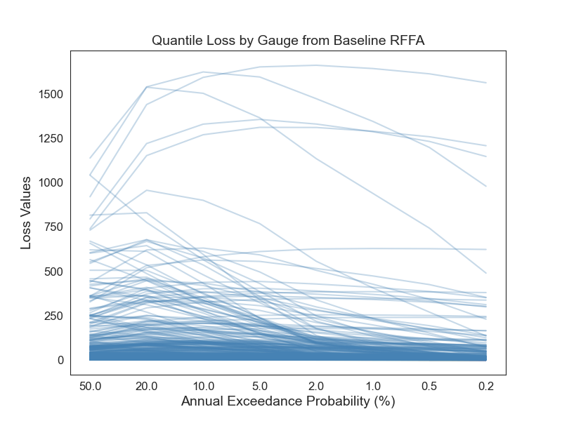

Figure A3: Gauge-level Quantile Loss from Baseline RFFA Model

Data reference: `reports/ML-exploration/ML-approach1-ma.ipynb`

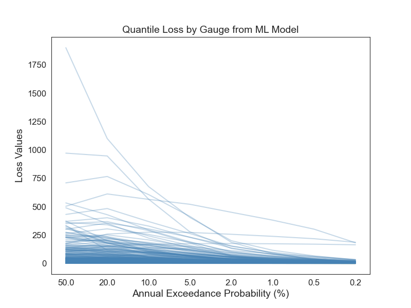

Figure A4: Gauge-level Quantile Loss from ML Model

Data reference: `reports/ML-exploration/ML-approach1-ma.ipynb`

#### IFM: Quantile Loss by Region

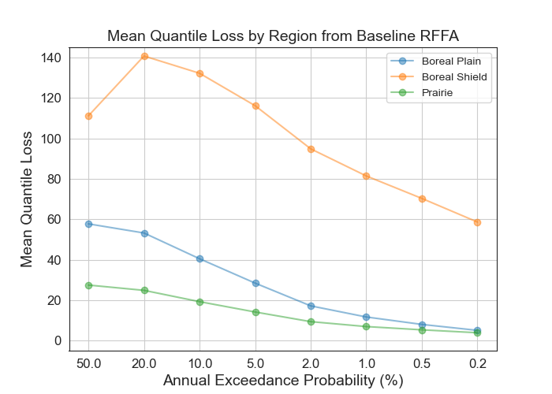

Data reference: `reports/ML-exploration/ML-approach1-ma.ipynb`

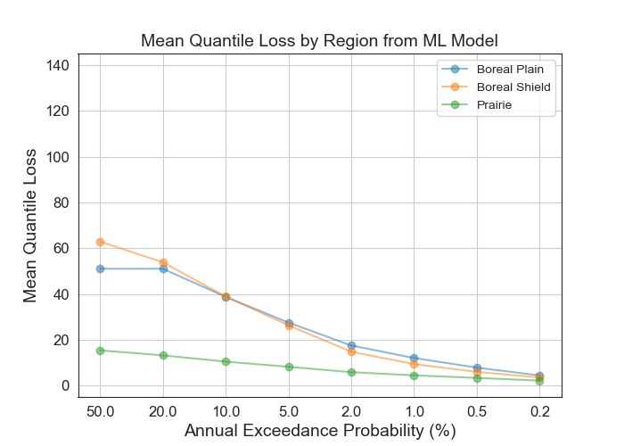

Data reference: `reports/ML-exploration/ML-approach1-ma.ipynb`

## Appendix: Supporting Analysis for Direct Quantile Prediction

There are 4 notebooks under the folder ‘report/Approach2’. The codes are basically the same, except the input/training data. Each notebook is for a specific region (Prairies, Boreal Shield, Boreal Plain, Overall) and contains everything, e.g models, coefficient importances, decreasing portions and “Max-out” behavior exploration, which will be explained below.

### DQM Data Preprocessing

Data preprocessing for DQM is pretty similar to IFM, except that loss functions of models used in DQM are quantile loss, a.k.a fidelity loss, in which case there is no need to implement weighted RMSE like what we did for IFM.

For the sake of non-duplicates, results/findings will be mainly focused on the ‘Overall’ region. For other regions, please refer to the corresponding notebooks.

**Table A6: DQM Preprocessing Steps**

| Step | What | Why |
| --- | --- | --- |
| 1 | Remove erroneous/missing data and control for edge cases | Removing data with N/A values ensures calculations can be completed successfully. |
| 2 | Convert instantaneous river flow values to log base-10 scale | Addresses skewness in the data |
| 3 | Scale all numeric watershed characteristics to a common scale (mean = 0 and variance = 1) | Scaling data ensures that all numeric features are on a similar scale, preventing one feature from dominating the model training process due to its larger magnitude. |

### Coefficient importance

Three models are used for DQM, Linear quantile regression, LightGBM quantile regression and Quantile random forest regression. Feature importances shown below come with models’ own implementation. Taking ‘overall’ region as an example:

Linear:

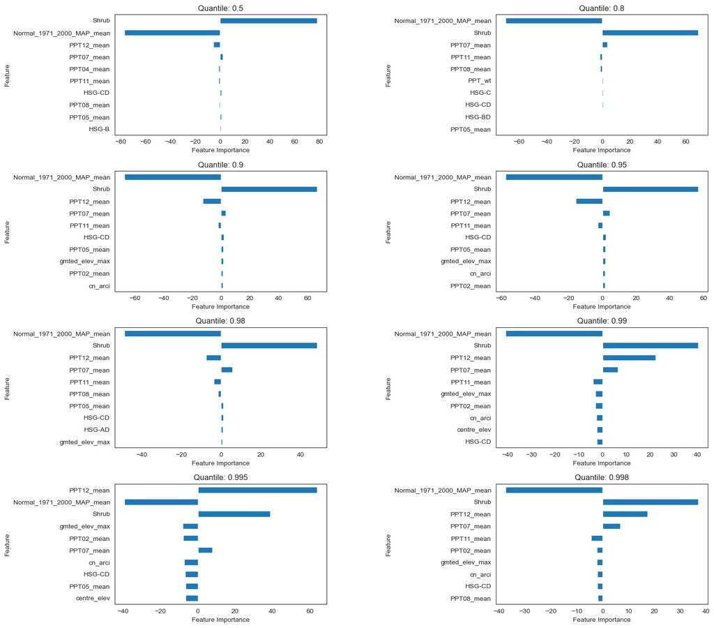

Figure A7: Coefficient Importance: Linear Quantile Regressor

Data reference: `reports/Approach2/quantile-overall.ipynb`

LightGBM:

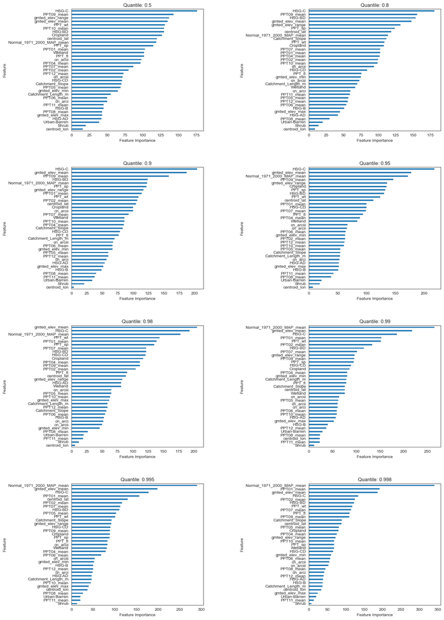

Figure A8: Coefficient Importance: LightGBM Quantile Regressor

Data reference: `reports/Approach2/quantile-overall.ipynb`

Random forest:

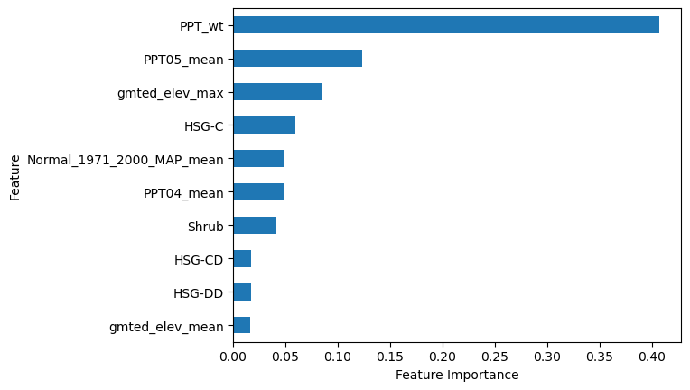

Figure A9: Coefficient Importance: Random Forest Quantile Regressor

Data reference: `reports/Approach2/quantile-overall.ipynb`

Generally speaking, feature importances present what we expect: flows are most correlated with precipitation and soil types.

However, for tree-based models’ feature importance, one thing to note is that models tend to favor numerical features more. Instead of taking what has been already implemented from packages, we should also consider doing a permutation feature importance, which has not been done in notebooks yet.

### “Max-out” Behavior

This section is mainly for exploration.

Theoretically speaking, quantile functions should “max-out” at some value, i.e. value beyond that quantile does not change. In order to explore this kind of behavior, models have been trained on 400 quantiles.

After training and testing with each test gauge, we do not see “max-out” behaviors with Linear and lightGBM, but we do see this with random forest sometime. It’s not pretty clear if this is because of package-specific implementation and needs to be further checked. Below is just one example:

[figure not shown]

Figure A10: Example of Max-Out Behaviour at One Gauge

Data reference: `reports/Approach2/quantile-overall.ipynb`

### Decreasing portion

This section is mainly for exploration.

Ideally, given the nature of quantiles, higher quantiles should always be larger or equal in magnitude than smaller quantiles. Decreasing portion refers to the proportion of quantiles from a model where higher quantiles may not always be larger in magnitude than smaller quantiles.

107 rivers in test set. We have 107*8 estimated quantiles. Numerator is the number of lower quantiles that is >= higher quantiles.

Linear: 105/856 Random Forest: 50/856 LighGB: 146/856

### Prediction Concerns

While the quantile loss scores of the models appear promising, it is important to acknowledge that these scores are averaged, obscuring the variability of the loss. Merely relying on the mean score fails to capture crucial information about the spread or shape of the quantile loss.

A concern of note with the direct quantile method is that the consistency and accuracy of predictions can vary considerably for different gauges. The figures below are examples of a bad and good (respectively) set of quantile predictions from the modeling test set. It is not currently understood what aspect of a gauge’s features cause the models to generate poor predictions. As with the IFM, it is necessary to exercise caution when employing direct quantile method predictions.

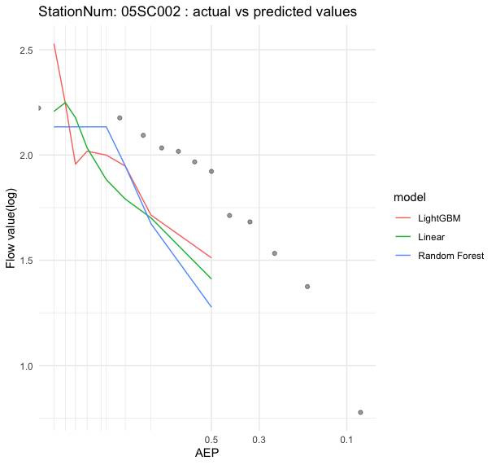

Figure A11: Example of Bad Gauge-level DQM River Flow Quantile Predictions

Data Reference: `reports/Approach2/good_bad.R`

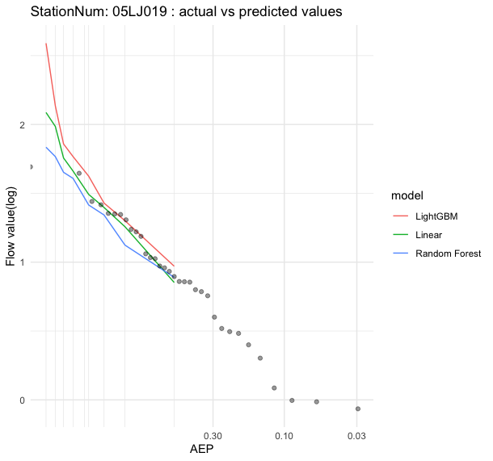

Figure A12: Example of Good Gauge-level DQM River Flow Quantile Predictions

Data Reference: `reports/Approach2/good_bad.R`

Unfortunately, unlike the IFM, there is no way to verify that the DQM presents empirical benefits over the existing method, as doing so would require a hydrologist to identify similar rivers for each of the hundreds of test set gauges. However, the ability of this method to produce reasonable predictions without any need for manual intervention suggests that this is a viable alternative to the direct quantile method currently used. In the future, verification could be achieved by comparing the predictions of this model to the model used in practice, ideally for rivers with well known flow values to establish a ground truth.

## Appendix: Choosing IFM or DQM

Both IFM and DQM are used in modern hydrology depending on context, and as such there is validity to presenting improvements to both methods. Consulting with BGC’s hydrologists, IFM is often the default selection, as it has more physically interpretable components (an index flood prediction and normalized growth curve) that provide transparency to the approach. However, IFM requires a region to have relatively homogenous watersheds. Homogeneity of gauges is required to fit a statistical distribution to a defined group. When this is unrealistic, the direct quantile method is used instead. Often more mountainous regions (i.e. British Columbia) rely on the direct quantile method, while more level regions (i.e. Boreal Plains) can use IFM.

## Appendix: Regional Homogeneity, Clustering and H-Index

The IFM relies on the assumption that all rivers pooled together to generate growth curves share the same underlying distribution of residual ratios (observed flow divided by the observed geomean of flow).

To validate this assumption, it is necessary to create subgroups of rivers which share highly similar growth curves, such that their normalized flow data can be pooled to create a single growth curve that describes the homogenous group.

Hierarchical clustering on the features of the watersheds is done to achieve this without manual intervention. Hierarchical clustering is preferred due to its flexibility to manually define the desired number of clusters, as well as the ability to define different linkage criteria. The “ward” criterion in the `scipy` implementation of hierarchical clustering was found to be ideal, as its criterion of equalized variance within clusters tends to create more evenly sized clusters and reduce the tendency for individual rivers to be labeled as outliers.

The goal of the hierarchical clustering undertaken on this project was to generate homogenous clusters, but also to provide physical interpretability. It was important for the differences between the clusters to be explainable, rather than being arbitrary labels.

The following criteria were used for clustering exploration, explained in detail in the subsections below.

1. Standard Deviation of Residual Ratios
2. Distribution of Variance Ratios
3. Physical/Principal Component Analysis (PCA) Interpretability
4. Heterogeneity Index (M. and Wallis 1997)

Overall, 4 clusters were selected based on the above criteria, formed by applying the clustering to all data pooled together. It was also separately found that subdividing the data by geo-region also increased homogeneity. The result was the formation of 12 clusters (4 clusters for each of 3 geo-regions).

### Cluster Interpretation

Overall, the clustering process was dominated by watershed areas. Because watershed area is known to account for the majority of variance in flow (National Research Council Canada, 1989), this is generally analogous to grouping rivers by their flow magnitude, though flow is not directly included in the process to allow for clustering of unmonitored rivers for prediction.

Cluster labels are generated arbitrarily, and it was found that Cluster 1 corresponds to very large watersheds (mean 955,000 km2), Cluster 2 to large watersheds (mean 307,000 km2), Cluster 4 to medium watersheds (mean 75,600 km2), and Cluster 3 to the smallest watersheds (mean 2,240 km2). It is worth noting that luster 3 represents approximately 90% of the training dataset, and is generally the cluster of greatest interest, as smallest rivers are least likely to be gauged. Clustering is not directly equivalent to grouping by size, as variance in all features is considered. However, many features are highly collinear with area. For example, mean centroid elevation also varies significantly between clusters, but this can be explained by considering that the largest watersheds tend to have the lowest elevation, as smaller, more alpine watersheds tend to be nested within large watersheds in lower valleys.

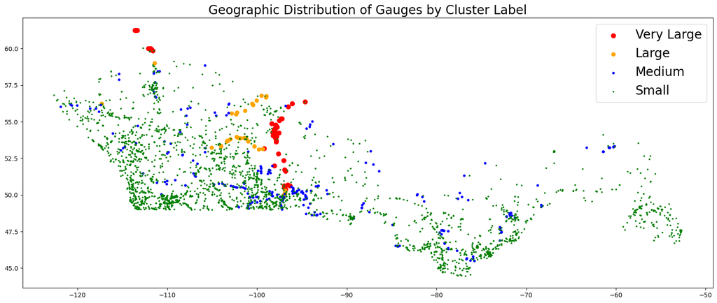

Figure A13: Geographic Distribution of Gauges by Cluster Label

Caption: Geographic distribution of gauges, colored by cluster label. Arbitrary cluster labels (1-4) have been replaced by relative watershed area, and scaled for visual clarity.

Data Reference: `reports/Clustering-Exploration/clustering-map.ipynb`

This figure shows the geographical distribution of gauges by watershed size. The large rivers can be easily oriented to major Canadian rivers, such as the upper left ‘very large’ gauges being the Slave River, the central parallel orange ‘large’ rivers being the Churchill and Saskatchewan rivers, etc. This map also illustrates the nesting aspect of some gauges described in the Appendix: Nested Gauge Structure, as many large rivers are gauged in multiple places, and the observed flow of the downstream gauges are clearly not independent of the upstream gauges.

It was found later in the project that the resolution of this clustering is probably not sufficient to meet the requirements of the IFM (see Appendix: Unable to Achieve High Homogeneity in Clustering). This was unable to be adjusted due to time constraints, and the necessity of refitting significant portions of the existing pipeline. However, this coarse clustering provided a basis from which to explore new methods, along with ensuring physical interpretability of clusters to guide downstream decision making. Refined clustering could potentially further increase the reliability of the IFM approach detailed here and is a route for further exploration.

### Criterion: Standard Deviation of Residual Ratios

The initial criterion used to evaluate clusters was the homogeneity of the standard deviation of residual ratios at each gauge. Gauges with similar spread of residual ratios can be theorized to have similar frequency magnitude curves. Gauges with large spread take on larger values at the highest quantiles, with the reverse being true of gauges with small spread, and so gauges that are identified as having similar features and sharing a growth curve by the clustering algorithm should also have similar standard deviations.

The figure below shows the initial results of this criterion. Standard deviation is plotted as error-bars around a fixed value of 0. The y-axis is in terms of residual ratio and is shared between all plots to allow for comparison. When generating clusters, these plots were used as a visual check, with the intention being to observe similar magnitudes of standard deviation within a cluster, and different magnitudes of standard deviation between the clusters. Initial exploration using elbow plots suggested three or four clusters, and it was found that increasing the number of clusters beyond four did not meaningfully improve the visuals of this plot.

It can be observed on this plot that the largest rivers (cluster 1) have the smallest standard deviation, and the smallest rivers (cluster 3) have the largest. This has a reasonable physical interpretation in terms of seasonal precipitation. The small cluster 3 rivers have relatively small watersheds, and so can be significantly affected by a particularly heavy period of local rain, or larger than normal snowmelt. Additionally, a difference of even a few cubic meters per second of flow would be represented as a large residual ratio for the smallest rivers due to their small mean. Conversely, the very large watersheds of the cluster 1 rivers would require higher than normal precipitation across exceedingly large areas, which is much more unlikely. Similarly, an increase of tens or even hundreds of cubic meters per second is required to produce comparably large residual ratios as are observed in cluster 3 rivers.

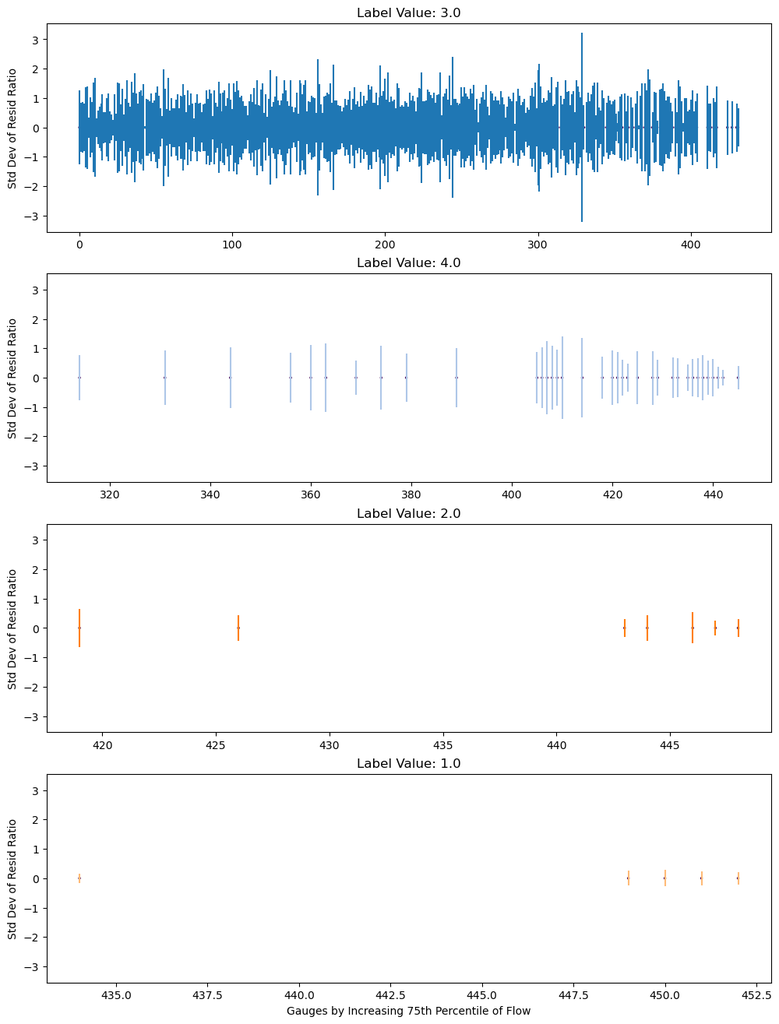

Figure A14: Standard Deviation of Residual Ratios by Cluster

Caption: Standard Deviation of Residual Ratios by Cluster (y-axis). X-axis sorts by magnitude of flow. Similar y-axis magnitudes within each cluster and different magnitudes between each cluster is desirable.

Data reference: `reports/Clustering-Exploration/clustering-expl.ipynb`

### Criterion: Distribution of Variance Ratios

Another criterion developed for this clustering approach was related to whether the variability of within-gauge variances in each group was as expected under homogeneity, or whether the spread was such that the observed differences are more likely due to heterogeneity.

If the group is truly homogenous, then the residual ratio values of each gauge can effectively be considered a random sample of the overall group. These random samples have the same expected variance as the overall group, with some variability due to sampling error. This variability should have specific distributional properties, and if the observed variability of gauges deviates from the expected distribution, we can conclude the observed difference is due to heterogeneity.

The criterion shown below was derived from Cochran’s Theorem, being specifically applicable to normally distributed random variables. Observations of the distribution of log(flow) for gauges show that they are roughly symmetrical and bell-shaped, and for gauges with sufficient number of observations the Central Limit Theorem allows for a reasonable assumption of normality.

$\frac{(n-1)\sigma^2_{gauge}}{\sigma_{group}^2} \sim \chi^2_{n-1}$

This provides us a variance ratio statistic and corresponding distribution that can be computed for each gauge. The closer the observed distribution of the statistics are to this theoretical distribution, the closer the variances of each gauge are to the overall variance, and the more homogenous the group.

In order to validate this, the non-exceedance probability of each statistic value for its corresponding $\chi^2_{n-1}$ distribution is computed. If the group is homogenous, these computed probabilities should be Uniform(0,1) distributed. To apply a visual check, the observed probabilities were plotted against the quantiles of the uniform(0,1) distribution. The resulting P-P (Probability/Probability) plot should lie as close as possible to the diagonal line. An example is shown below. This criterion was specifically used to determine that dividing rivers by geo-region produced more homogenous clusters.

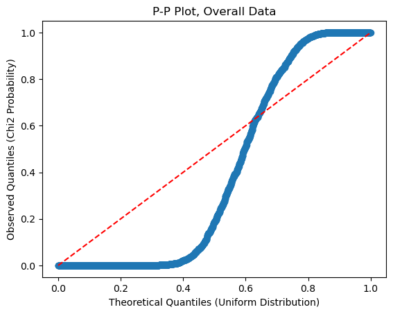

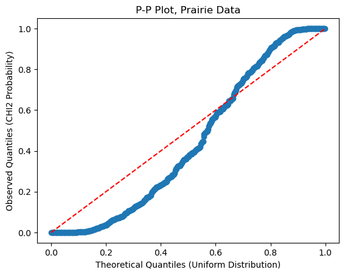

Caption: P-P Plots for overall data vs prairie region only, plotting observed $\chi^2$ non-exceedance probabilities against the uniform (0,1) distribution. A fit along the diagonal red line indicates homogeneity.

Data reference: `reports/Clustering-Exploration/clustering-expl.ipynb`

Distribution of probabilities for all gauges pooled together is observed to be significantly farther from the diagonal than probabilities for all prairie gauges, indicating the prairies are closer to homogeneity. This supports subdividing gauges by region.

### Criterion: Physical/Principal Component Analysis (PCA) Interpretability

The physical interpretability of clusters was considered a significantly important criterion to gain confidence in the new approach. It was considered preferable to have significant physical evidence for the separation of clusters, rather than a fine resolution of clustering, with largely arbitrary labels and no clear way to distinguish between them. This was done partially through evaluating the mean feature values within each cluster, but also through Principal Component Analysis (PCA) visualization.

PCA can provide a visual ‘summary’ of the similarities and differences of highly multidimensional data points. In this case, 51 numeric watershed characteristics are summarized by two latent feature vectors, which cumulatively account for 55% of the total variation observed in the data. The PCA feature values of individual gauges can be plotted in two dimensions, with small distances between gauges indicating similarity, and vice versa.

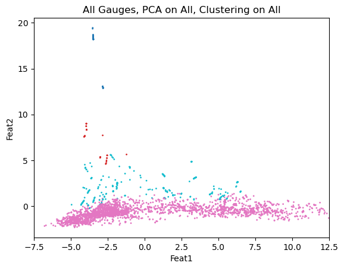

Figure A16: PCA Visualization

Caption: Plot showing latent similarities between gauges in each cluster label. Feat2 (y-axis) corresponds mostly to watershed area, while Feat 1 (x-axis) corresponds mostly to precipitation. Cohesive groups with minimal mixing is desirable.

Data reference: `reports/Clustering-Exploration/clustering-expl.ipynb`

The figure above shows the results of PCA on all gauges, along with corresponding colored markings for their hierarchical cluster labels (n = 4). Analysis of the feature weights showed that Feat2 (y-axis) is largely correlated with the watershed area, and Feat1 (x-axis) is largely correlated with precipitation. The relative dominance of watershed area in the clustering process is visible here by the horizontal color banding.

This plot represents a positive clustering outcome under this criterion, with each hierarchical cluster label being also relatively grouped together by the PCA algorithm, with minimal mixing between the clusters. Experimentation with other cluster numbers, or clustering on regionalized data, resulted in PCA plots with unclear boundaries and/or significant mixing of labels, indicating less interpretable clusters.

t-SNE (t-distributed stochastic neighbor embedding) clustering was also explored as an option for this criterion but was not found to be clearer than PCA plotting. PCA plotting was selected due to the added benefit of feature interpretability for the latent vectors.

### Criterion: Heterogeneity Index (Hosking and Wallis, 1997)

The heterogeneity test outlined in Regional Frequency Analysis (M. and Wallis 1997) chapter 4.3 is the current standard criterion for group homogeneity used in hydrological practice. This was unfortunately not known to the MDS team until late in the project and would have significantly changed the clustering approach taken.

The heterogeneity index, or H-Index, is a test for how heterogenous a group is using the method of l-moments. Even if a group of gauges is truly homogenous, with their residual ratio of flows being drawn from the same underlying distribution, their observed l-moments will not necessarily be the same due to sampling error. The H-index compares the spread of observed L-CVs (L-coefficient of variation, observed variance divided by observed mean) in a group to the L-CVs of a simulated homogenous population, generated from a kappa distribution, with the parameters being the mean l-moments of the observed group.

It is computed as follows, with $V$ being the standard deviation of observed L-CVs weighted by observations per gauge, $\mu_V$ being the mean $V$ generated by the simulation, and $\sigma_V$ being the standard deviation of $V$ values generated by the simulation.

$H = \frac{V- \mu_V}{\sigma_V}$

H < 2 is desirable to establish ‘possibly homogenous’ clusters.

The H-index was used as evidence confirm that dividing by region does yield more homogenous clusters, and that generally the boreal shield is the most heterogenous of the clusters in this investigation, with the plains and prairies having more homogenous watersheds, which matches the hydrological understanding.

However, H-index also shows that the resolution of clustering undertaken in this analysis was not sufficient to validate the IFM assumptions, particularly for cluster 3.

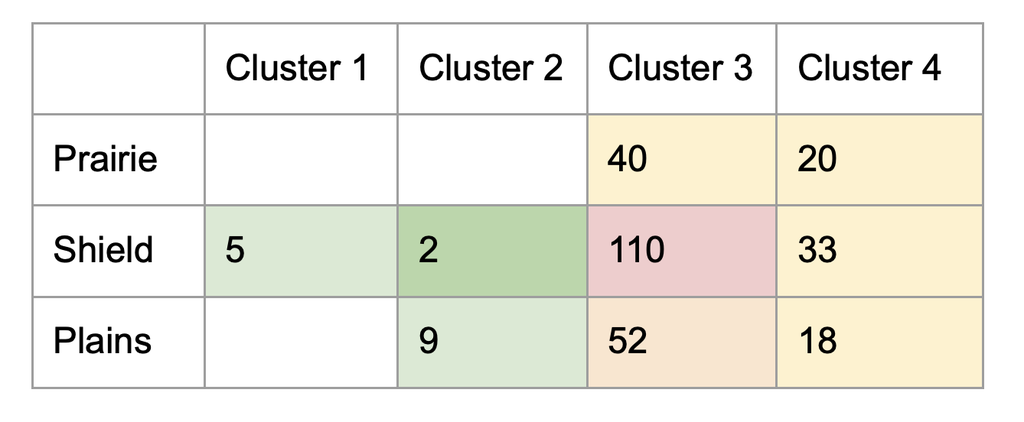

Table A7: H-Index Per Region and Cluster

Caption: Table showing H-index values for each region/ cluster combination. Some combinations are missing due to insufficient data.

Data reference: `reports/Clustering-Exploration/h-index/h-index.ipynb`

The H-indexes of the region/cluster combinations are shown above. It is worth noting that the standard of H < 2 may be too harsh in practice, as the only place this is validated is in Shield Cluster 2, which is composed of multiple gauges along a single river.

Additionally, in normal practice, a discordancy test is administered, and gauges that negatively affect the H-index of their corresponding cluster can be removed from the training set. However, this should be viewed as a fine-tuning measure and would not sufficiently improve these scores.

### Classifying Clusters

When receiving new gauges, it is necessary to assign them a cluster label to pass them to the correct growth curve. Due to the lack of ‘prediction’ capacity in the hierarchical clustering algorithm, it is necessary to re-cluster each new gauge – effectively adding the new gauge to the training data and reapplying the clustering algorithm.

It was found through experimentation that the difference of a single data point does not appear sufficient to affect the structure of the clusters – which would be a concern because the labels 1-4 are arbitrary. To ensure consistency, when predicting multiple gauges with the script, each is re-clustered separately to prevent the addition of multiple gauges distorting clustering.

One issue of note is that providing very large numbers (i.e. all values 100,000, when many features are proportions ranging from 0-1) is sufficient to restructure the clusters and generate an erroneous arbitrary label. This type of error is potentially realistic for unit scaling errors, data mis-entries, or other issues.

### Clustering Recommendations and Limitations

Unfortunately, due to lack of time, as well as significant downstream dependencies on early clustering, the MDS team was not able to refit clusters in accordance with the H-index criterion. Despite this, the proposed IFM still shows significant promise, and could likely be further improved by increasing the number of clusters.

It is important to note that there is a significant trade-off between establishing homogeneity within clusters and maintaining the benefits of pooling. The literature criterion of H < 2 is likely too strict, as the size of clusters required to meet this standard would be extremely small and would likely result in many clusters containing only single gauges. This effectively compromises the benefits of the IFM, as the intention is to pool together data from multiple gauges to create a more reliable estimation of the growth curve. Additionally, while predicting cluster labels of new gauges is reliable for small numbers of clusters, it is likely far more challenging for large numbers of clusters. Interpretability of clusters would also be significantly decreased.

Overall, the H-index suggests that finer clustering is necessary to increase homogeneity and improve the reliability of the residual ratio distributions. This is a definite step that could be taken to further improve the predictions generated by the MDS Team’s approach. Discordancy checks could also be run to fine tune clusters by removing problematic gauges. However, a balance must be struck to ensure the value of pooling is maintained. Even if gauges in a cluster are not fully homogeneous, they may at least be similar enough to justify their grouping into a single cluster. Realistically, no two watersheds are truly homogenous, and some relaxation of this IFM assumption appears necessary for it to function. An alternative method that allows for partial relaxation of the IFM assumption is also detailed in the Expanded Future Improvements. However, it is evident that this assumption was over-relaxed in the MDS Team’s current approach, and there is significant potential benefit to finer clustering.

## Appendix: Expanded Limitations and Future Improvements

### Expanded Limitations

#### Data Structure

##### Variable Amounts of Data at Gauge Level

The current ML algorithm for training the index flood prediction model within the Index Flood Method does not directly account for the variable number of years of data across different gauges. The issue with this is that there may be a representation bias present in the data, where well-gauged rivers are very well represented (longer data record). A variability in the amount of data available per gauge may also lead to unintended issues with flow variance at gauge level, as smaller sample sizes may have larger variance due to observing a high return period flood by chance. Our algorithm depends on the flow variance at gauge level to train and tune models correctly (see IFM Evaluation Metric Selection section).

##### Grouped Data and Train-Test Splits

The data is structured in a “grouped” or “hierarchical” fashion, where multiple years of data are available for each gauge, and there are multiple gauges. To avoid leakage of training data into the test data, data within a gauge cannot be split between the train and test set. A consequence of this is that a 70% train / 30% test data split refers to a 70-30 split at the gauge level only. For example, it could be possible due to random chance that a 70% train split is equivalent to only 40% of the actual rows of data if those 70% of gauges all happen to be gauges with very few years of data. A symptom of this is that weighted-RMSE scores in the test set are much higher than cross-validation scores, but are vastly improved when the size of the test set is increased. This shows that scores are sensitive to the amount of data being allocated to the train versus test split. In the future, different sizes of train and test split could be experimented with more thoroughly.

##### Nested Gauge Structure

It is possible for a large watershed to contain multiple smaller watersheds. As an extension of this, it is possible for the large watershed to have one gauge, and the smaller watersheds within it to also all have one gauge. This results in a nested data structure, where river flow measurements across different gauges can no longer be considered independent. This could be addressed via a data cleaning exercise to eliminate known nested gauges where the area of the different watersheds is very similar. There will always be some degree of nesting in river flow data, as rivers flow toward the ocean and combine to form larger rivers. It would be up to the domain experts at BGC to determine what level of nesting is acceptable. A similar issue arises when considering multiple gauging, as the largest rivers in the dataset are often gauged in multiple locations. In the case above where many small rivers contribute to a large river, the large river is only partly dependent on each of the small rivers. However, with sequential gauges, the downstream gauge observations may be fully dependent on the upstream observations, with the difference of watershed area between the gauges accounting for only a small fraction of the observed flow.

##### Testing Dataset Composition

The test set for model evaluation was constructed randomly. However, there may have been a benefit to experimental ‘blocking’ by manually constructing test sets to ensure that relevant subgroups (i.e. clusters, regions) were equally represented in the test set. However, due to the extensive manual effort required to create multiple large test sets, this was not pursued.

#### Algorithmic and ML Limitations

##### Quantile Scores not Scaled to River Size

Quantile loss is used for model training in the quantile prediction method. Quantile loss is a linear function of error magnitude. Larger rivers with larger flow magnitudes will tend to have larger errors, and therefore larger quantile scores. When training, minimization of large river error will be favored. This could be addressed by introducing a weighting parameter, similar to the strategy implemented in the Index Flood Method, but is not as drastic as in IFM because it is linear, not quadratic.

##### No Accessible “Ground Truth” for DQM

There is no easily accessible baseline for comparison in the DQM approach. The conventional direct quantile prediction method requires an experienced hydrologist to manually cluster and collect similar rivers. This is difficult to recreate at scale for all rivers at the same level of efficiency as the ML models.

##### Index Flood Method: Challenging Prairie Data

The prairie region is the worst-performing region for the index flood prediction, with the worst numerical scores and the largest spread in the predicted vs actual plots. This might be attributed to the absence of suitable factors that properly explain the prairie hydrology. Discussions with BGC hydrologists suggest that region specific features such as the Prairie Potholes have significant influence over prairie hydrology, and their influence may not be fully captured by our available watershed features. Without these factors, the ML model is not able to properly explain the variance in the annual maximum flows.

#### Statistical Assumptions

##### Unable to Achieve High Homogeneity in Clustering

Index flood model still relies on homogeneity. While we use regionalization and clustering to improve, it isn’t fully achieved by our clustering under the H-index criterion. This criterion was unfortunately not known to the MDS team until late in the project, and there were already many downstream dependencies to the early clustering regime. Further improvements to the quantile predictions of the IFM could be achieved by applying hierarchical clustering with a greater number of clusters. It should be noted that this may introduce problems with the statistical benefits of pooling, physical interpretability of clusters, and prediction of cluster labels for new rivers. See Regional Homogeneity, Clustering and H-Index appendix for a thorough discussion.

##### Overprediction / Choice of Statistical Distribution

The figures below visualize IFM gauge-level predictions of the RFFA models compared to the FFA benchmark at the design flood (0.5% AEP). Low dispersion around the diagonal line is ideal, indicating that the RFFA prediction is close to the FFA benchmark. There is slight evidence of lower dispersion in the ML model figure. This indicates the ML model predictions are generally closer to the FFA benchmark than predictions made by the conventional RFFA modeling process. The figures also show evidence of overprediction by the ML model compared to the FFA, this is discussed as a limitation in the Appendix: Overprediction / Choice of Statistical Distribution section.

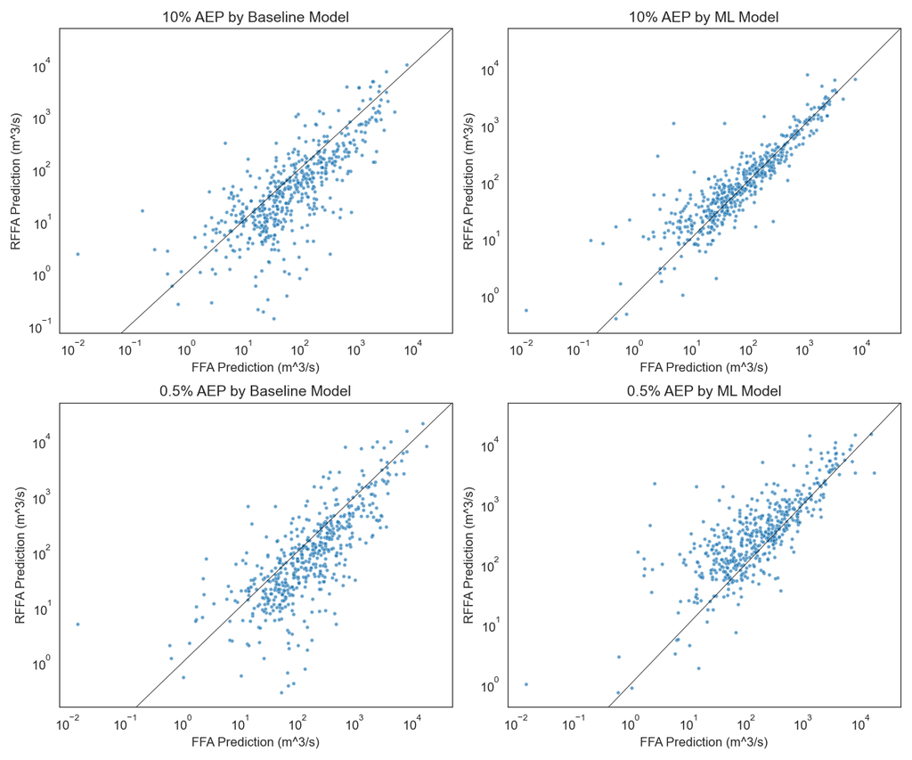

Figure A17: Comparison of FFA Predictions to RFFA Predictions for River Flow Quantiles

Caption: Comparison of RFFA vs FFA predictions at gauge level for the design flood (0.5% AEP). Chart show evidence of slightly lower dispersion around diagonal in ML models vs baseline. Charts show evidence of overprediction in ML models vs baseline model.

Data reference: `reports/ML-exploration/ML-approach1-ma.ipynb`

FFA vs RFFA plot shows that our model over-predicts at high quantiles, while the baseline model exhibits underprediction at high quantiles. This could be due to the use of Log Pearson Type III for residual ratios. Log Pearson Type III exhibited the best fit via mean quantile score for quantiles of interest, but it may be an overpredictor for higher quantiles. In the short term this could be addressed by quantifying the degree of bias and applying a scale factor, but further investigation is needed.

##### Distribution Selection Methodology

The most appropriate statistical distribution was fit to the residual ratio data based on the highest mean quantile score. There are other ways to determine the best distribution, including AIC and BIC criteria, QQ and PP plots, and tests such as the Kolmogorov-Smirnov and Anderson-Darling tests.

#### Data Product Limitations

##### Limited Manual Intervention Ability

There is currently no functionality in the data product for domain experts to manually intervene in the prediction pipeline in any way. For example, if end users wish to remove a particular gauge from the available data, they would need to remove it from the raw data, re-train the ML models, override saved models, then re-run the prediction scripts. To avoid filtering input data, users could instead modify the ML model training code to include functionality to customize training weights in the dataset (increase importance or omit gauges). This could take the form of a new function argument that takes an array of length X_train, defaulting to all 1s. Any gauges to exclude could be given a value of 0; gauges that should be 50% weighted could be given a value of 0.5, etc. Multiply variance weight scores by this array to get final sample weights. Regardless of the solution implemented, manual intervention requires re-training models and possibly redoing hyperparameter tuning.

##### Model Training not Scripted

The model training process was not scripted, but instead models were iteratively developed within notebooks. If end users wish to re-train the machine learning models explored in this analysis, they will need to rerun the `.ipynb` notebooks used to create the models.

##### Limited DQM Hyperparameter Tuning

Hyperparameter tuning takes significant processing time. Per ML model, it can take between 10 to 90 minutes to complete hyperparameter tuning. The Direct Quantile Method requires one ML model per quantile of interest. This can quickly inflate the number of ML models that require hyperparameter tuning. As a result, hyperparameter tuning was not explored in this project for DQM. Hyperparameter tuning has the capacity to greatly improve the prediction accuracy of the quantile prediction models, and should be explored in the future.

### Expanded Future Improvements

#### Mixed Effects Model

Explore a mixed effects model with year as its own effect. Some years have more data due to more gauges in operation. Peaks in these years may be very similar (i.e. a very rainy year) and so may be overrepresented in the dataset. This was not explored in this analysis due to time constraints.

#### Data Augmentation

Implement data augmentation by regression on daily maxima vs instantaneous maxima. This analysis is based solely on instantaneous daily maxima, which is more effective for FFA than daily average maxima. However, there are techniques to estimate the instantaneous daily maxima from the average daily maxima when instantaneous is not available. This was not explored in this analysis due to time constraints and the presence of a suitable amount of instantaneous daily maxima data.

#### Visual Outlier Detection

Could visualize when a watershed is “unusual” with respect to clustering. This could be visualized using principal component analysis plots (see Appendix: Regional Homogeneity, Clustering and H-Index), with the new watershed’s location in the plot being highlighted to determine if its cluster label appears appropriate, and that the watershed’s features are well represented in the training data. Alternatively, a different clustering method able to identify outliers (i.e. DBSCAN) could be applied to flag input rivers as potential outliers. DBSCAN is probably not a suitable replacement for hierarchical clustering in the creation of pooled distributions due to the flexibility of hierarchical clustering, and the necessity of equal density clusters for DBSCAN, which we do not have. However, if a new data point is flagged as an outlier by an appropriately tuned DBSCAN algorithm, this could be a sign that it is an outlier.

#### New Clustering Techniques

Use hierarchical clustering approach with finer clusters (greater ‘n’) to increase the validity of the assumption of homogeneity. See Appendix: Regional Homogeneity, Clustering and H-Index.

#### New Quantile Modelling Paradigm

Given the difficulties with establishing truly homogenous clusters in the IFM (see Appendix: Regional Homogeneity, Clustering and H-Index), this suggests that there may be room for an intermediate model between the current IFM and DQM. Under the current IFM, it is assumed that the only difference between grouped gauges is the index flood value, whereas under the DQM, there are no assumed similarities between gauges. An intermediate method could assume that the geometric mean, variance, and possibly skewness (first three l-moments) are different for grouped gauges. Like the index flood, these values could be included as ML predictions. With these quantities allowed to vary within groups, it would be far easier to satisfy the IFM’s assumption of homogeneity. This is a novel approach that is not represented in the literature, and so would take extensive experimentation and theoretical validation to convince stakeholders of its validity, and so is merely suggested as a future avenue of further research.

#### Continuous DQM Predictions

Could implement a continuous prediction for DQM, similar to that of lFM. Due to the nature of quantile prediction models, it is necessary to either train a new model for each quantile, or to pre-specify a list of quantiles for DQM. This means that the data product can only output predictions for set, pretrained quantiles for DQM. It is possible to create a continuous prediction by training more quantile models and fitting a probability distribution to the resulting values, but this was not implemented due to time constraints. More quantile models can be trained using training notebooks.

# References

EGBC. 2018. “Legislated Flood Assessments in a Changing Climate in BC.” *EGBC*. https://www.egbc.ca/getmedia/f5c2d7e9-26ad-4cb3-b528-940b3aaa9069/Legislated-Flood-Assessments-in-BC.pdf.

*Hydrology of Floods in Canada*. 1989. National Research Council, Canada, Associate Committee on Hydrology.

M., Hosking J R, and James R. Wallis. 1997. *Regional Frequency Analysis an Approach Based on l-Moments*. Cambridge University Press.